# Literate programming for creating and maintaining packages

Abstract

“Literate programming for creating and maintaining packages” published in R News.

*Jonathan Rougier*

## Outline

I describe a strategy I have found useful for developing large packages with lots of not-obvious mathematics that needs careful documentation. The basic idea is to combine the ‘noweb’ literate programming tool with the Unix ‘make’ utility. The source of the package itself has the usual structure, but with the addition of a noweb directory alongside the R and man directories. For further reference below, the general directory tree structure I adopt is where ‘. . . ’ denotes other optional directories such as src and data.

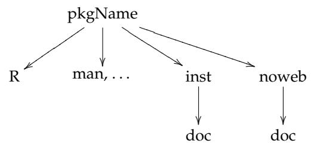

The files in the noweb directory are the entry-point for *all* of the documented code in the package, including *.R files, *.Rd files, low-level source code, datasets, and so on. The `noweb` tool, under the control of the file ‘Makefile’ and the Unix `make` utility, is used to strip the files in the `noweb` directory into the appropriate places in the other directories. Other targets in ‘Makefile’ also handle things like building the package, installing it to a specific location, cleaning up and creating various types of documentation.

A complete example R package is available at http://maths.dur.ac.uk/stats/people/jcr/myPkg.tar.gz containing the code below, and a bit more to make ‘myPkg’ into a proper R package.

## Literate programming and `noweb`

The basic idea of *literate programming* is that when writing complicated programs, it makes a lot of sense to keep the code and the documentation of the code together, in one file. This requires a mechanism for treating the file one way to strip out and assemble the code, and another way to create the documentation. With such a mechanism in place, the functionality of the code can be made much more transparent—and the documentation much more informative—because the code itself can be written in a modular or ‘bottom-up’ fashion, and then assembled in the correct order automatically.

I use the `noweb` literate programming tool. A `noweb` file looks like a $\LaTeX$ file with additional environments delimited by `<<name of environment>>=` and `@`. These define code chunks that appear specially-formatted in the documentation, and which get stripped out and assembled into the actual code. Here is an example of a minimal `noweb` file, called, say, ‘myDoc1.nw’.

```
\documentclass[a4paper]{article}
\usepackage{noweb}\noweboptions{smallcode}
\pagestyle{noweb}
```

```
\begin{document}
```

Here is some $\LaTeX$ documentation. Followed by the top-level source code.

```
<<R>>=
# The source of this file is noweb/myDoc1.nw
<<foo function>>
<<bar function>>
@
```

Now I can describe the `[[foo]]` function in more detail, and then give the code.

```
<<foo function>>=
"foo" <- function(x) 2 * x^2 - 1
@
```

And here is the `[[bar]]` function.

```
<<bar function>>=
"bar" <- function(y) sqrt((1 + y) / 2)
@
```

```
% stuff for man page not shown
\end{document}
```

The `[[name]]` syntax is used by `noweb` to highlight variable names. There are many additional features of `noweb` that are useful to programmers. More information can be found at the `noweb` homepage, http://www.eecs.harvard.edu/~nr/noweb/.

## Tangle

`noweb` strips out the code chunks and assembles them using the ‘notangle’ command. One useful feature is that it can strip out chunks with specific identifiers using the `-R` flag. Thus the command `notangle -RR myDoc1.nw` will strip all the code chunks identified directly or indirectly by `<<R>>=`, assembling them in the correct order. The result of this command is the file which is written to standard output. By redirecting the standard output we can arrange for this file to go in the appropriate place in the package directory tree. So the full command in this case would be `notangle -RR myDoc1.nw > ../R/myDoc1.R`. So as long as we are consistent in always labelling the ‘top’ chunk of the R code with an `<<R>>=` identifier, we can automate the process of getting the R code out.

```
# The source of this file is noweb/myDoc1.nw
"foo" <- function(x) 2 * x^2 - 1
"bar" <- function(y) sqrt((1 + y) / 2)
```

If we want, we can do the same thing using `<<man>>=` for the content of man pages, `<<src>>=` for low-level code, `<<data>>=` for datasets, and so on. Each of these can be stripped out and saved as a file into the appropriate place in the package directory tree.

## Weave

To build the documentation, `noweb` uses the ‘noweave’ command, where it is useful to set the `-delay` option. Again, this is written to the standard output, and can be redirected to place the resulting $\LaTeX$ file at the appropriate place in the package tree. I put the $\LaTeX$ versions of the *.nw files in the directory `noweb/doc`. Thus the appropriate command is `noweave -delay myDoc1.nw > doc/myDoc1.tex`. This file contains quite a lot of $\LaTeX$ commands inserted by `noweb` to help with cross-referencing and indexing, and so is not particularly easy to read. But after using `latex`, the result is a dvi file which integrates the $\LaTeX$ documentation and the actual code, in a very readable format.

April 13, 2005 myDoc1.nw 1

Here is some L<sup>A</sup>T<sub>E</sub>X documentation. Followed by the top-level source code.

```
⟨R⟩≡
# The source of this file is noweb/myDoc1.nw
⟨foo function⟩
⟨bar function⟩
```

Now I can describe the `foo` function in more detail, and then give the code.

```
⟨foo function⟩≡
"foo" <- function(x) 2 * x^2 - 1
```

And here is the `bar` function.

```
⟨bar function⟩≡
"bar" <- function(y) sqrt((1 + y) / 2)
```

## Using make

Our starting point is a collection of `*.nw` files in the `noweb` subdirectory. We could, by hand, issue a series of `notangle` and `noweave` commands, each time we update one or more of these files. Happily, the Unix tool `make` can be used instead. `make` requires a file of specifiers, often called ‘Makefile’, which describe the kinds of things that can be made, and the commands necessary to make them. Obvious candidates for things we would like to make are the `*.R` and `*.Rd` files that go into the `R` and `man` subdirectories, and the documentation that goes into the `inst/doc` subdirectory.

The `make` utility is very powerful, and complicated. I am not an expert at writing a ‘Makefile’, but the following approach seems to work well. My Makefile lives in the `noweb` directory, and all of the path specifiers take this as their starting point.

### Simple make targets

Suppose that we have compiled a list of files that ought to be in the `R` subdirectory (say, ‘RFILES’), and we want to use the command ‘`make R`’ to update these files according to changes that have occurred in the `noweb/*.nw` files; the argument `R` is known as a ‘target’ of the `make` command. We need the following lines in Makefile:

```
# make R files in ../R
```

```
R:      $(RFILES)
```

```
$(RFILES):      %.R : %.nw
    @echo 'Building R file for $<'
    @notangle -RR $< > ../R/$@
    @if test 'egrep '^<<man>>=' $<' ; then \
        notangle -Rman $< > ../man/$*.Rd ; fi
```

After the comment, prefixed by `#`, the first line states that the command ‘`make R`’ depends on the files in the list ‘RFILES’, which we have already compiled. The next set of lines is executed for each component of ‘RFILES’ in turn, *conditionally on the `*.R` file being older than the corresponding `*.nw` file*. Where the `*.R` file is out-of-date in this way, a message is printed, `notangle` is called, and the `*.R` file is rebuilt and placed in the `R` subdirectory; if there is a `<<man>>=` entry, the `*.Rd` file is also rebuilt and placed in the `man` subdirectory.

A ‘Makefile’ has its own syntax. Within a target specification, the tags ‘`$<`’, ‘`$@`’ and ‘`$*`’ indicate the origin file, the result file, and the file stem. Under each initial line the collection of subsequent commands is indented by tabbing, and the backslash at the end of the line indicates that the next line is a continuation. The `@` at the start of each command line suppresses the printing of the command to the standard output.

The attractive feature of `make` is that it only rebuilds files that are out-of-date, and it does this all automatically using information in the file date-stamps. This saves a lot of time with a large package in which there are many `*.nw` files in the `noweb` directory. In my experience, however, one feels a certain loss of control with so much automation. The useful command ‘`make --dry-run R`’ will print out the commands that will be performed when the command ‘`make R`’ is given, but not actually do them, which is a useful sanity check. The command ‘`touch myDoc1.nw`’ will change the date-stamp on ‘myDoc1.nw’, so that all derived files such as ‘myDoc1.R’ will automatically be out-of-date, which will force a rebuild even if ‘myDoc1.nw’ has not been modified: this can be another useful sanity-check.

Suppose instead we want to rebuild the L<sup>A</sup>T<sub>E</sub>X documentation in the `noweb/doc` subdirectory, using the command ‘`make latex`’. We need the following lines in ‘Makefile’:

```
# make latex files in doc
```

```
latex: $(TEXFILES)
```

```
$(TEXFILES):      %.tex : %.nw
    @echo 'Building tex file for $<'
    @noweave -delay $< > doc/$@
```

```
@cd doc; \
  latex $@ > /dev/null
```

where ‘TEXFILES’ is a list of files that ought to be in the `noweb/doc` subdirectory. As before, each `*.tex` file is only rebuilt if it is out-of-date relative to the corresponding `*.nw` file. The resulting `*.tex` file is put into `noweb/doc`, and then `latex` is called to create the corresponding `*.dvi` file (rather lazily, the output from `latex` is diverted to `/dev/null` and lost).

Slightly more complicated, suppose we want to put pdf versions of the `*.tex` files into the subdirectory `inst/doc`, using the command ‘make pdf’. We need the following lines in ‘Makefile’:

```
# make pdf files in ../inst/doc

pdf:    $(TEXFILES) $(PDFFILES)

$(PDFFILES):    %.pdf : %.tex
    @echo 'Building pdf file for $<'
    @cd doc; \
        pdflatex $< > /dev/null;
    @mv doc/$@ ../inst/doc/
```

where ‘PDFFILES’ is a list of files that ought to be in the `inst/doc` subdirectory. The new feature here is that the command ‘make pdf’ depends on both ‘TEXFILES’ and ‘PDFFILES’. This means that each component of ‘TEXFILES’ is updated, if necessary, *before* the `*.pdf` file is rebuilt from the `*.tex` file. To rebuild the `*.pdf` file, the `pdflatex` command is called on the `*.tex` file in `noweb/doc`, and then the result is moved to `inst/doc`.

### Additional lines in the ‘Makefile’

The main role of additional lines in ‘Makefile’ is to supply the lists ‘RFILES’, ‘TEXFILES’ and so on. The following commands achieve this, and a little bit else besides, and go at the start of ‘Makefile’:

```
## minimal Makefile

# look in other directories for files
vpath %.R ../R
vpath %.tex doc
vpath %.pdf ../inst/doc

# get lists of files
NWFILES = $(wildcard *.nw)
RFILES = $(NWFILES:.nw=.R)
TEXFILES = $(NWFILES:.nw=.tex)
PDFFILES = $(NWFILES:.nw=.pdf)

# here are the various targets for make

.PHONY: R latex pdf install

# Now insert the lines from above ...
```

The three ‘vpath’ lines are necessary to help make to look in other directories than `noweb` for certain types of file. Thus the `*.R` files are to be found in `../R`, the `*.tex` files in `doc`, and so on (all relative to the `noweb` directory). The next four lines compile the lists of various types of file: ‘NWFILES’ are found in the `noweb` directory, ‘RFILES’ are ‘NWFILES’ files with the ‘nw’ suffix replaced with a ‘R’ suffix, and so on. For the final line, the `.PHONY` command is a bit of defensive programming to identify the targets of the `make` command.

#### Example

The file http://maths.dur.ac.uk/stats/people/jcr/myPkg.tar.gz contains a small example of an R package created using `noweb` and `make`, where there is only one `*.nw` file in the `noweb` directory, namely `myDoc1.nw`. The following commands illustrate the steps outlined above (‘debreu’ is my computer):

```
debreu% make --dry-run R
make: Nothing to be done for 'R'.
debreu% touch myDoc1.nw
debreu% make --dry-run R
echo 'Building R file for myDoc1.nw'
notangle -RR myDoc1.nw > ../R/myDoc1.R
if test 'egrep '^<<man>>=' myDoc1.nw' ; then \
    notangle -Rman myDoc1.nw > ../man/myDoc1.Rd ; fi
debreu% make R
Building R file for myDoc1.nw
debreu% make --dry-run pdf
echo 'Building tex file for myDoc1.nw'
noweave -delay myDoc1.nw > doc/myDoc1.tex
cd doc; \
    latex myDoc1.tex > /dev/null
echo 'Building pdf file for myDoc1.tex'
cd doc; \
    pdflatex myDoc1.tex > /dev/null;
mv doc/myDoc1.pdf ../inst/doc/
debreu% make pdf
Building tex file for myDoc1.nw
Building pdf file for myDoc1.tex
```

Initially the source file `myDoc1.nw` is up-to-date. I touch it to make it more recent than the derived files `myDoc1.{R,Rd,tex,pdf}`. The dry run shows the commands that will be executed when I type `make R`: in this case the file `myDoc1.R` is built and moved to `../R`. After issuing the command `make R` the only output to screen is the comment ‘Building R file for `myDoc1.nw`’. The dry run for `make pdf` shows a more complicated set of operations, because before `myDoc1.pdf` can be built, `myDoc1.tex` has to be built.

### More complicated targets

The `make` command can also be used to perform more complicated operations. Two that I have found useful are building the package, and installing the package onto my `$R_LIBS` path. In both cases, these operations must first make sure that the files are all up-to-date. For ‘make install’, for example, we might have:

```
PKGNAME = myPkg
RLIBRARY = /tmp/
R = R

# install

install:      $(RFILES) $(PDFFILES)
    @echo 'Installing $(PKGNAME) at $(RLIBRARY)'
    @cd ../..; \
        $(R) CMD INSTALL -l $(RLIBRARY) $(PKGNAME)
```

where the variables ‘PKGNAME’, ‘RLIBRARY’ and ‘R’ are specified separately, so that it is easy to change them for different packages, different locations on $R_LIBS or different versions of R. These are best put at the top of the ‘Makefile’. The target `install` should be added to the .PHONY line.

Issuing the `make install` command when everything is up-to-date gives:

```
debreu% make --dry-run install
echo 'Installing myPkg at /tmp/'
cd ../..; R CMD INSTALL -l /tmp/ myPkg
debreu% make install
Installing myPkg at /tmp/
* Installing *source* package 'myPkg' ...
** R
** inst
** help
>>> Building/Updating help pgs for package 'myPkg'
    Formats: text html latex example
* DONE (myPkg)
```

If some of the files were not up-to-date then they would have been rebuilt from the original *.nw files first.

## Conclusion

The great thing about literate programming is that there is no arguing with the documentation, since the documentation actually includes the code itself, presented in a format that is easy to check. For those of us who use L<sup>A</sup>T<sub>E</sub>X, `noweb` is a very simple literate programming tool. I have found using `noweb` to be a good discipline when developing code that is moderately complicated. I have also found that it saves a lot of time when providing code for other people, because the programmer’s notes and the documentation become one and the same thing: I shudder to think how I used to write the code first, and then document it afterwards.

For large projects, for which the development of an R package is appropriate, it is often possible to break the tasks down into chunks, and assign each chunk to a separate file. At this point the Unix `make` utility is useful both for automating the processing of the individual files, and also for speeding up this process by not bothering with up-to-date files. The ‘Makefile’ that controls this process is almost completely generic, so that the one described above can be used in any package which conforms to the outline given in the introduction, and which uses the tags ‘R’, ‘man’ and so on to identify the type of code chunk in each *.nw file.